# Webscrape, Corpus, and Visualizations - Ghost Guns

Coffy Andrews-Guo

11/22/2021

## Ghost Guns

Evolving Trend - Unserialized and Untraceable FireArms

[figure not shown]

Science | HowStuffWorks

What are ghost guns? *Ghost guns are unserialized and untraceable firearms that are constructed by individuals using unfinished frames or receivers. They are available for purchase by anyone, including prohibited purchasers, domestic abusers, and gun traffickers – without a background check.*

Federal Regulations

*The gun laws do not require a background check to purchase a ghost gun kit or parts because the receivers and frames are unfinished. An individual can legally purchase a receiver or frame that is 80-percent complete or less, then modify the parts with a drill press or power drill, a router jig, and other components into an effective and reliable firearm.*

### Sentiment on Ghost Guns

Webscrape Newspaper Articles with `xml2 and rvest package`  
URL links the selected newspaper articles was loaded, each individual text body was selected with [SelectorGadget](https://selectorgadget.com/) in Chrome. The `SelectorGadget` extracted the HTML nodes form these newspapers article text-body:

1. The Federalist - [3-D Printed Guns Are A Reminder That Gun Control In America Is Futile](https://thefederalist.com/2018/08/02/3-d-printed-guns-reminder-gun-control-america-futile)
2. The Guardian - [Ordered online, assembled at home: the deadly toll of California’s ‘ghost guns’](https://www.theguardian.com/us-news/2021/may/18/california-ghost-guns-deadly-toll)
3. Chicago Tribune - [Ghost guns: What they are, and why they are an issue now](https://www.chicagotribune.com/nation-world/ct-aud-nw-nyt-cb-ghost-guns-20210409-v7osb6gxvfgdneo6z7v5dupdt4-story.html)

```r
federalist.root.html <- read_html("https://thefederalist.com/2018/08/02/3-d-printed-guns-reminder-gun-control-america-futile/")
federalist.body <- federalist.root.html %>%
  html_nodes("p") %>%  # indicates node name
  html_text(trim = TRUE)

names(federalist.body) <- c("newspaper") # insert new column for newspaper name

federalist.body <- as_tibble(federalist.body)

federalist.body$newspaper <- "Federalist"
```

### Create Corpus

A corpus format will store the newspapers textual data, `.body`, for text analysis.

```r
corpus <- rbind(federalist.body, guardian.body, tribune.body)
corpus <- Corpus(VectorSource(corpus))

#inspect(corpus)
```

#### Transform: Cleaning the Corpus

Using the `tm package` the corpus is formatted before any analysis by performing these transformations: tolower, removePunctation, removeNumbers, and remove stopwords.

#### Create a term-document matrix

The term-document matrix will compare all the terms or words across each document. The tdm results was sorted and summarized in a decreasing order. The selected `Ghost Guns articles`top 5 frequent words pertain to *gun, guns, ghost, said, and violence*.

```
##              word freq
## gun           gun   77
## guns         guns   64
## ghost       ghost   55
## said         said   23
## violence violence   20
```

### Word Cloud

Visualization of words

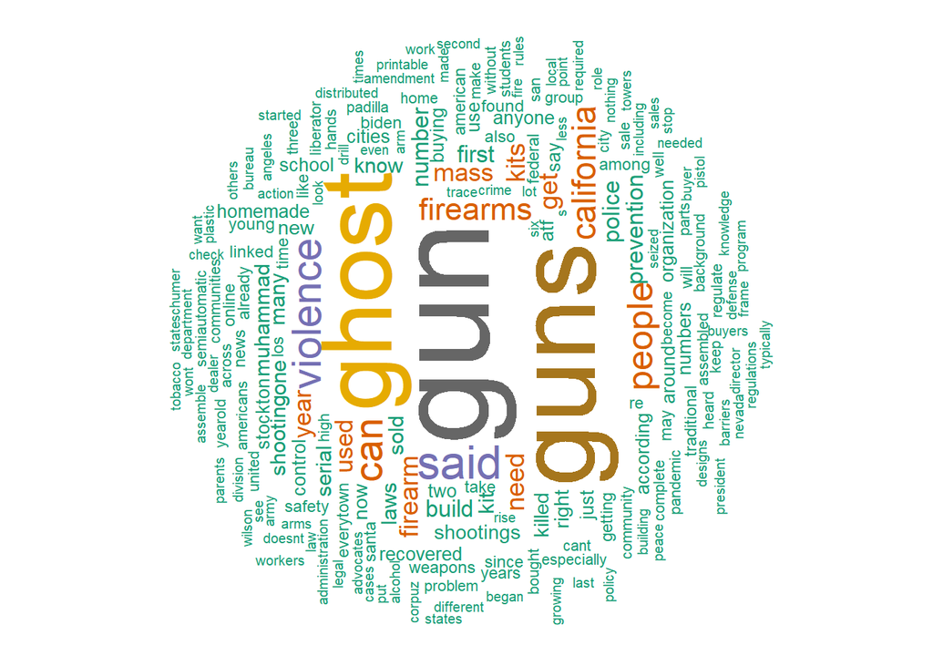

The above word cloud clearly shows that “gun”, “guns”, “ghost”, “violence”, and “said” are the five most important words in the Corpus.

### Public Sentiment Analysis

The `syuzhet package` will pull out the eight basic emotions as well as positive and negative sentiment from the selected newspaper articles. The expanding accessibility of ghost guns (aka: homemade weapons, or do-it-yourself guns) in our communities may create disparity where negative and positive sentiments are equally influential on emotions. The highest three emotions: fear, anger, and trust, also indicates the level of intensity a ghost gun as a firearm.

```
##   anger anticipation disgust fear joy sadness surprise trust negative positive
## 1     1            0       0    1   0       0        0     0        1        0
## 2     0            0       0    0   0       0        0     0        0        0
## 3     0            0       0    1   0       0        0     0        0        0
## 4     0            0       0    0   0       0        0     0        0        0
## 5     1            0       0    1   0       1        0     0        1        0
```

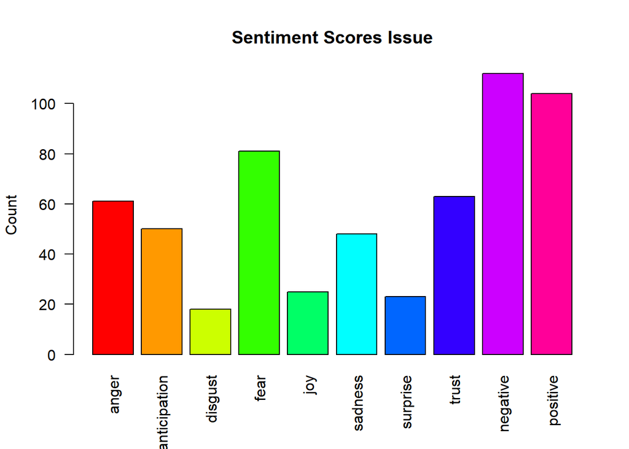

### Conclusion

The selected articles are based on three political views towards ghost guns. The sentiment scores shows a high intensity of *fear* and it signals that society recognizes the influence ghost guns play in mass shootings, as an undetectable, unregulated, firearm. Although the federal Bureau of Alcohol, Tobacco, and Firearms (ATF) and state agencies enforces gun laws, ghost guns are not defined as " a firearm".